# Exploring flight patterns above The Netherlands

Visualizations of 3.5 million datapoints

flights

visualisation

Author

Jesse van Elteren

Published

April 22, 2020

Some years ago I woke up early because of a loud aircraft flying over. Couldn’t get back to sleep and decided to use these precious early hours to visualize the air traffic around Hilversum.

Every aircraft is equipped with a device called a [transponder](https://en.wikipedia.org/wiki/Transponder) that transmits flight data about the flight into the air. Organizations like [OpenSky](https://opensky-network.org/) aggregate these data and make them available. Below a screenshot of the result, you can see the tracks and some information about the flight is displayed.

[figure not shown]

When reading this post on a computer, I recommend zooming in with ctrl + mousewheel. On mobile it’s with your fingers :) Use the buttons on the right to zoom in on the map. If you see a bright white line over your hometown, there is probably a lot of air traffic flying over.

Let’s see if there are more interesting patterns and visualisations. First we split the traffic by altitude.

**Start or landing**

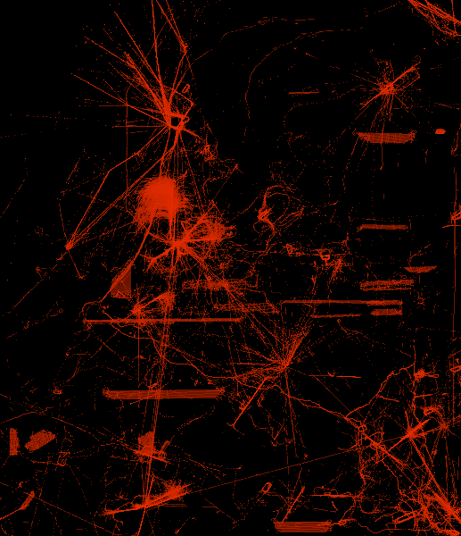

**Departure/arrival**

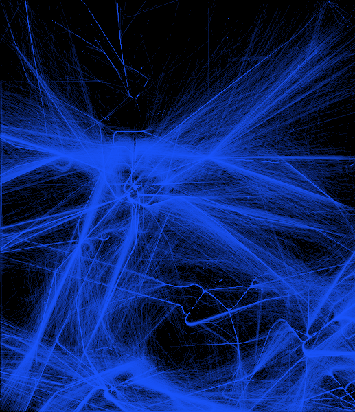

**Aircraft passing**

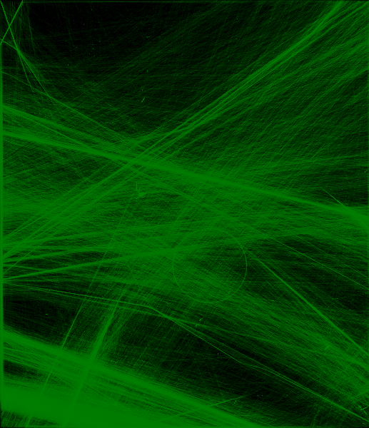

- Red: The lowest flying traffic. Airfields such as Eelde, Eindhoven, Dusseldorf and Brussels are visible.
- Blue: All the complex movements of traffic in and out of Amsterdam. These are standard routes being flown to keep the traffic manageable, so called [STARs](https://nl.wikipedia.org/wiki/Standard_terminal_arrival_route) and [SIDs](https://en.wikipedia.org/wiki/Standard_instrument_departure).
- Green: The highest flying aircraft are passing over in mostly straight tracks.

There are more properties in the data, such as altitude, vertical speed and velocity.

**Vertical rate (red=desc)**

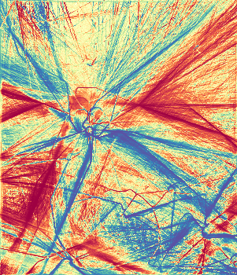

**Mean altitude per 1000m**

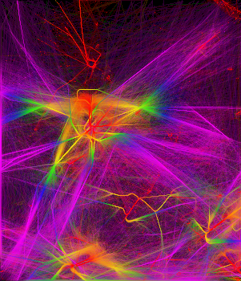

**Mean velocity, dark=slow**

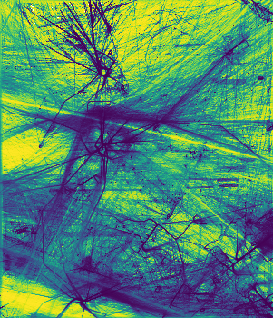

- Left: all the arriving flights are red and departures are blue.
- Middle: This disco shows aircraft climbing or descending. The colormap is increasing with 1000m per color, starting from red for 0-1000m. Compare it with the left graph: departing flights are quickly climbing to purple, whereas arrivals are flying lower longer. The green to yellow transitions indicate the points where arrival flights are converging for their approach.
- Right: the average speed of the aircraft. Also here you see arrival routes are darker (slower) than departures.

And because COVID-19 is here, let’s plot the data of the past weeks.

[interactive chart not shown]

**2020-03-09**

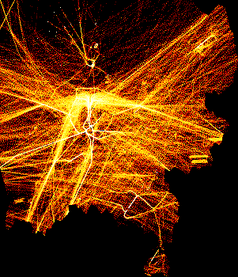

**2020-03-16**

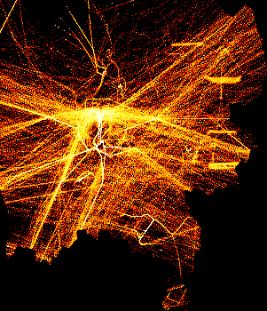

**2020-03-23**

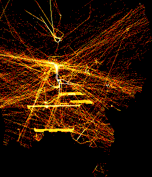

**2020-03-30**

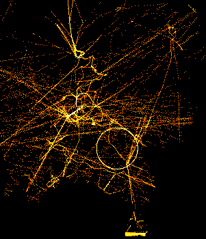

**2020-04-06**

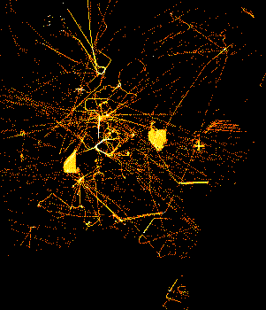

**2020-04-13**

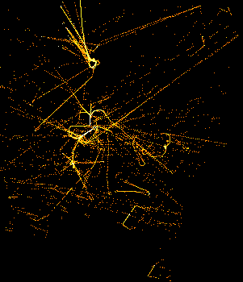

‘Normally’ there are 2700 flights above the Netherlands (including some North Sea) with a total airtime of 840 hours per day. That is the equivalent of about 35 aircraft flying continuously. The graph shows the dramatic slowdown to about 1/8 of the original volume.

The firelike image on the left side is slowly turning into a collection of night flies: the slowdown of traffic can be easily seen. This has been analyzed more extensively [here](https://traffic-viz.github.io/scenarios/covid19.html).

I also went through callsigns that occur most often. Grouping different types of traffic results in some interesting patterns. A small quiz: which pattern belongs to: - The coastguard - Aerial photography - Military flights - Emergency care flights (trauma) - Police helicopters - Commercial helicopter flights

**A**

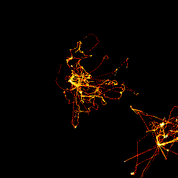

**B**

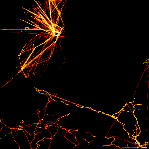

**C**

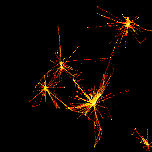

**D**

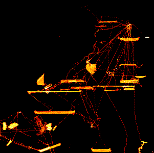

**E**

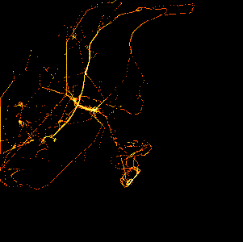

**F**

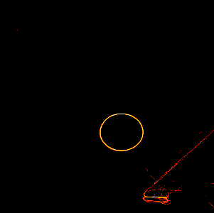

Let’s end with some visualisations with a certain shade of blue. What type of flights do they represent?

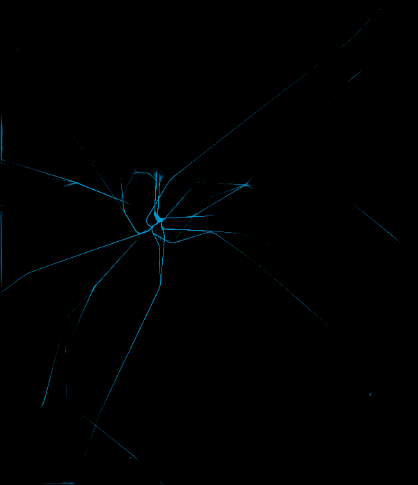

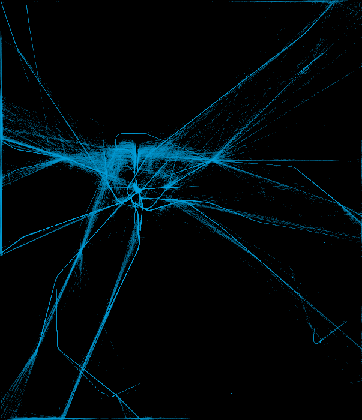

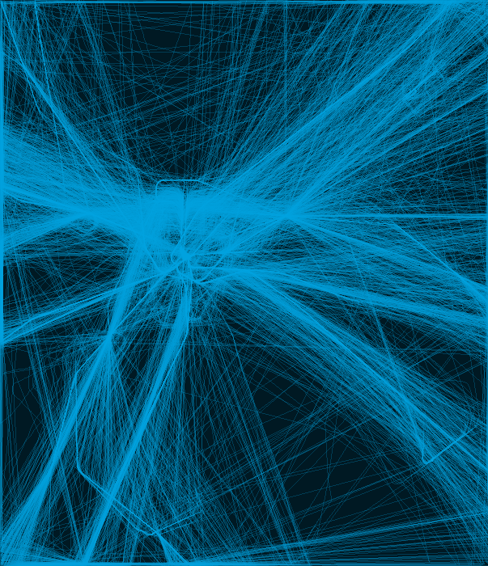

That’s it, I had fun visualizing all of this, hope you enjoyed reading it!

And the blues represent our flagship carrier KLM! If you want you can [download](https://github.com/jvanelteren/blog/raw/master/_notebooks/flight/large%20scale%20flight%20visualisations.zip) the higher resolution images

**Tip**

Thanks to OpenSky, Datashader and some wonderful tutorials on the internet, e.g. [US Census](https://anaconda.org/jbednar/census/notebook) and [PyViz](https://examples.pyviz.org/opensky/opensky.html). I used code from these examples as well.

**Note**

[Here you can find my other posts](https://jvanelteren.github.io/blog/)